# Assignment 1- Sports Analytics Literature & Data Review

Ankit Singh

9/25/2020

## Part 1: An open access sports data set

### 1.1 Information and variables in the dataset

The dataset relates to an international sport called Cricket where basically 2 teams with 11 players each compete against one another. This dataset contains information about a particular player and his performances in One Day International format of the game.

Cricket being my favorite sport and AB de Villiers being my most favorite cricketer, I am choosing this particular dataset which talks about his ODI batting performances from his debut in 2005. The dataset contains different kinds of variable information about his batting performances over a number of years right from his debut. From variables like his individual scores to his mode of dismissals, the venue, the date, his strike rate, number of balls faced and so many other aspects are covered about him. In summary, the dataset consists of 12 variables and 189 lines of records.

#### 1.1.2 Variables

Formally, the 12 variables are following:

- Runs
- Mins
- BF
- 4s
- 6s
- SR
- Pos
- Dismissal
- Inns
- Opposition
- Ground
- Start Date

#### 1.1.3 Source and the time period of the data

The main source of the data is the master branch under cricketr package in Github repository. The time span of the dataset goes from 2 Feb 2005 to 19 Aug 2015. The last commit on the branch dataset was done on 27 Dec 2015.

#### 1.1.4 The dataset access

install.packages(“ggplot2”) install.packages(“tidyverse”) install.packages(“dplyr”)

```r
library(ggplot2)
library(tidyverse)
library(dplyr)

deVilliers <- read.csv("C:/Users/ankit/Desktop/Sem 3/Sports Analytics in Practice/Assignment 1/deVilliers.csv")
View(deVilliers)
```

### 1.2 Critical Appraisal

#### Possible questions under sports analytics

- Was de Villiers a better performer at opening slot(1/2) or in middle order(3/4/5)?
  - Did de villiers bat better while chasing(Innings 2) or setting(Innings 1) the target?
  - Does de Villiers really have a strike rate of more than 100 everytime he scored a 100 in an ODI ?
  - Does de Villiers have a special liking to West Indies in particular as an opponent ?

#### Unlikely questions

- Why is ‘caught’ the most no. of dismissals out of all ? DOesn’t it seem like questioning an event which is bound to happen maximum times in this sport ?

### 1.3 Basic exploratory data visualizations

```r
str(deVilliers)
```

```
## 'data.frame':    188 obs. of  13 variables:
##  $ X         : int  1 2 3 4 5 6 7 8 9 10 ...
##  $ Runs      : Factor w/ 108 levels "0","0*","1","1*",..: 35 29 101 34 85 31 44 39 54 42 ...
##  $ Mins      : Factor w/ 104 levels "-","1","10","101",..: 79 62 48 9 35 1 52 58 10 64 ...
##  $ BF        : int  38 28 14 7 7 29 25 23 67 29 ...
##  $ X4s       : Factor w/ 17 levels "-","0","1","10",..: 11 10 2 2 3 11 11 11 13 12 ...
##  $ X6s       : Factor w/ 10 levels "-","0","1","16",..: 2 2 3 2 2 2 3 3 2 3 ...
##  $ SR        : num  52.6 57.1 64.3 28.6 100 ...
##  $ Pos       : Factor w/ 7 levels "-","1","2","3",..: 3 3 3 3 3 2 2 2 4 3 ...
##  $ Dismissal : Factor w/ 7 levels "-","bowled","caught",..: 3 3 4 3 3 3 3 4 6 3 ...
##  $ Inns      : Factor w/ 3 levels "-","1","2": 3 3 2 2 3 3 3 2 3 3 ...
##  $ Opposition: Factor w/ 15 levels "v Asia XI","v Australia",..: 4 4 4 4 15 14 14 1 1 9 ...
##  $ Ground    : Factor w/ 61 levels "Abu Dhabi","Adelaide",..: 11 51 15 25 51 52 52 17 24 51 ...
##  $ Start.Date: Factor w/ 188 levels "1-Feb-08","1-Jul-07",..: 56 157 166 183 57 26 31 39 63 149 ...
```

```r
summary(deVilliers)
```

```
##        X               Runs          Mins           BF              X4s
##  Min.   :  1.00   0      : 14   -      : 15   Min.   :  0.00   0      :31
##  1st Qu.: 47.75   2      :  5   117    :  4   1st Qu.: 16.00   1      :26
##  Median : 94.50   24     :  5   23     :  4   Median : 37.00   3      :22
##  Mean   : 94.50   4      :  5   26     :  4   Mean   : 42.66   2      :21
##  3rd Qu.:141.25   17     :  4   46     :  4   3rd Qu.: 69.25   5      :13
##  Max.   :188.00   29     :  4   47     :  4   Max.   :130.00   6      :13
##                   (Other):151   (Other):153                    (Other):62
##       X6s            SR         Pos      Dismissal  Inns           Opposition
##  0      :115   Min.   :  0.00   -: 8   -      : 8   -: 2   v Pakistan   :31
##  1      : 30   1st Qu.: 61.58   1:16   bowled :19   1:97   v Australia  :23
##  2      : 13   Median : 87.50   2:20   caught :94   2:89   v India      :23
##  -      :  8   Mean   : 88.06   3:12   lbw    :14          v England    :21
##  3      :  7   3rd Qu.:112.41   4:98   not out:31          v West Indies:21
##  4      :  7   Max.   :338.63   5:32   run out:17          v New Zealand:18
##  (Other):  8                    6: 2   stumped: 5          (Other)      :51
##             Ground        Start.Date
##  Centurion     : 17   1-Feb-08 :  1
##  Port Elizabeth: 13   1-Jul-07 :  1
##  Durban        : 12   1-Nov-13 :  1
##  Cape Town     : 10   10-Apr-07:  1
##  Johannesburg  :  9   10-Jun-07:  1
##  Harare        :  6   10-Jun-13:  1
##  (Other)       :121   (Other)  :182
```

```r
class(deVilliers)
```

```
## [1] "data.frame"
```

```r
head(deVilliers)
```

```
##   X Runs Mins BF X4s X6s     SR Pos Dismissal Inns    Opposition         Ground
## 1 1   20   56 38   3   0  52.63   2    caught    2     v England   Bloemfontein
## 2 2   16   39 28   2   0  57.14   2    caught    2     v England Port Elizabeth
## 3 3    9   21 14   0   1  64.28   2       lbw    1     v England      Cape Town
## 4 4    2   11  7   0   0  28.57   2    caught    1     v England    East London
## 5 5    7   15  7   1   0 100.00   2    caught    2    v Zimbabwe Port Elizabeth
## 6 6   17    - 29   3   0  58.62   1    caught    2 v West Indies  Port of Spain
##   Start.Date
## 1   2-Feb-05
## 2   4-Feb-05
## 3   6-Feb-05
## 4   9-Feb-05
## 5   2-Mar-05
## 6  14-May-05
```

```r
tail(deVilliers)
```

```
##       X Runs Mins BF X4s X6s     SR Pos Dismissal Inns    Opposition     Ground
## 183 183   24   16  9   1   2 266.66   4    caught    1     v Ireland   Canberra
## 184 184   77  111 58   7   5 132.75   5    caught    2    v Pakistan   Auckland
## 185 185   99  115 82   6   4 120.73   4    caught    1      v U.A.E. Wellington
## 186 186    0    -  0   -   -   0.00   -         -    2   v Sri Lanka     Sydney
## 187 187  65*   84 45   8   1 144.44   5   not out    1 v New Zealand   Auckland
## 188 188    9   12  9   1   0 100.00   4    caught    1 v New Zealand  Centurion
##     Start.Date
## 183   3-Mar-15
## 184   7-Mar-15
## 185  12-Mar-15
## 186  18-Mar-15
## 187  24-Mar-15
## 188  19-Aug-15
```

```r
mean(as.numeric(deVilliers$'Runs'))
```

```
## [1] 48.88298
```

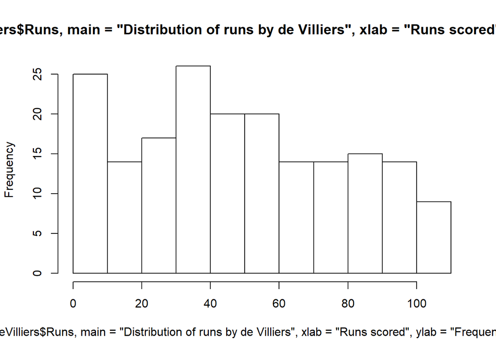

```r
hist(as.numeric(deVilliers$'Runs',main= "Distribution of runs by de Villiers", xlab="Runs scored", ylab="Frequency", col="Green"))
```

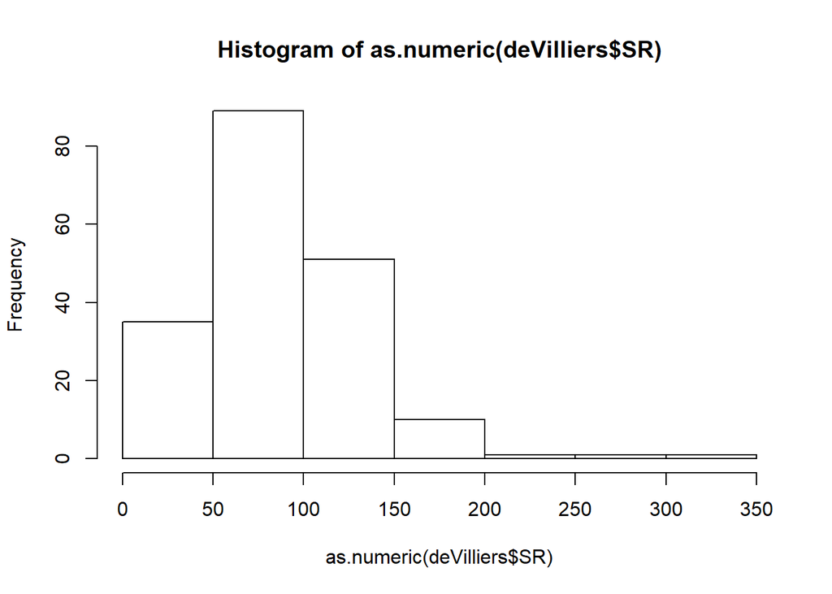

```r
hist(as.numeric(deVilliers$'SR'))
```

## Part 2: An analytics piece

### 2.1: Analysis of dataset chosen in part 1

As this piece of analytics tutorial, i am going to visit step by step process of what i have done with the dataset, deVilliers. During this walkthrough, i am going to analyze the code i wrote and the visualization it shows as results.

Step 1:

I click on the link provided and choose a dataset on my favorite sport, Cricket. Being a batsman dominant sport this, I select my favorite batsman’s dataset file, “deVilliers.csv”.

Step 2:

The dataset contains pretty raw data. Therefore, it needs some data cleaning and sorting which i did in the csv file only, to make dataset more uniform and ready to use.

Step 3:

Install all the necessary packages and libraries. After setting the working directory in RStudio, import the dataset by calling the csv dataset file from the location or path of the file.

Step 4:

Using view() function, we view, read and observe the dataset thoroughly in RStudio. There are some 188 rows of records provided in the dataset, deVilliers, with 13 columns.

Step 5:

I do some exploratory data visualization in support of description of data to make it more detailed and understandable for readers. I run commands like str(deVilliers),summary(deVilliers),class(deVilliers),head(deVilliers),tail(deVilliers) to view and take data in different forms and tables.

As part of exploratory analysis, basic plots and graphs like summary tables, histogram, scatterplot are drawn using ggplot library.

Step 6:

In the end, we can play around the data and draw different visualizations and explain them.

### 2.2 Data Visualization

We can draw different visualizations using ggplot and plotly library and understand what the data reveals in various ways. Following are few of the examples of R chunks and respective data visualization using deVilliers.csv-

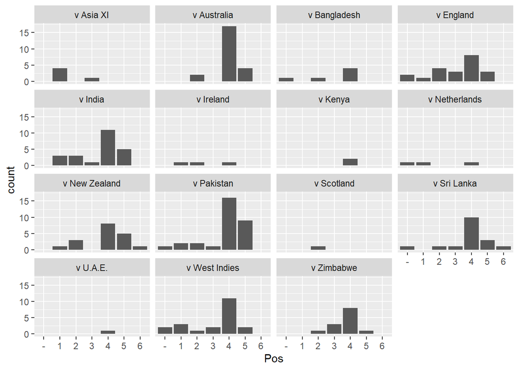

```r
ggplot(deVilliers, aes(x = Pos)) +
  geom_bar() +
facet_wrap(~Opposition)
```

The above piece of code shows the visualization of batting position of AB de Villiers versus different oppositions. If we observe closely, we can find out few things like-

1. De Villiers batted mostly at no. 4 position against all the oppositions almost.
2. The only 2 teams against which de Villiers batted at position 6, although only once or twice, are New Zealand and Sri Lanka.
3. De Villiers opened the innings either at position 1 or 2 very very few times, that too early on in his career. He never opened against Kenya and UAE while against India, de Villiers opened maximum no. of times.

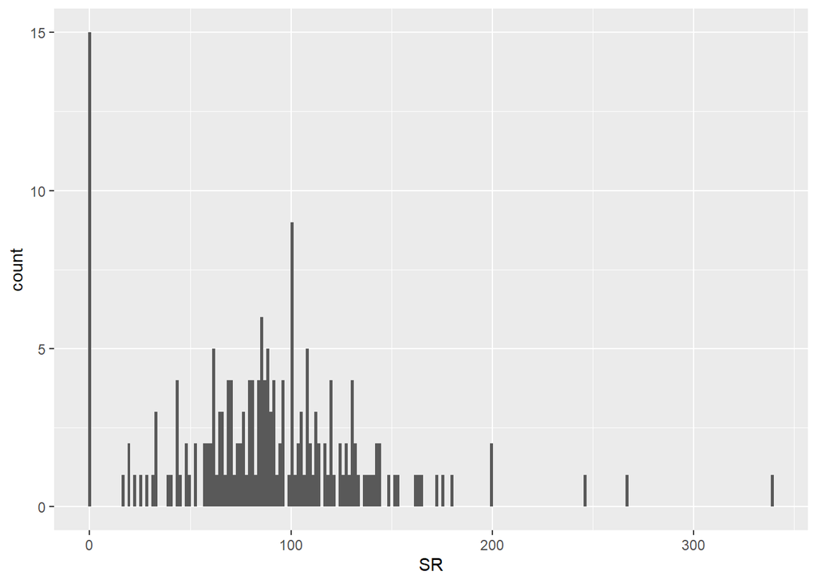

```r
ggplot(deVilliers, aes(SR)) + geom_histogram(binwidth = 1.5)
```

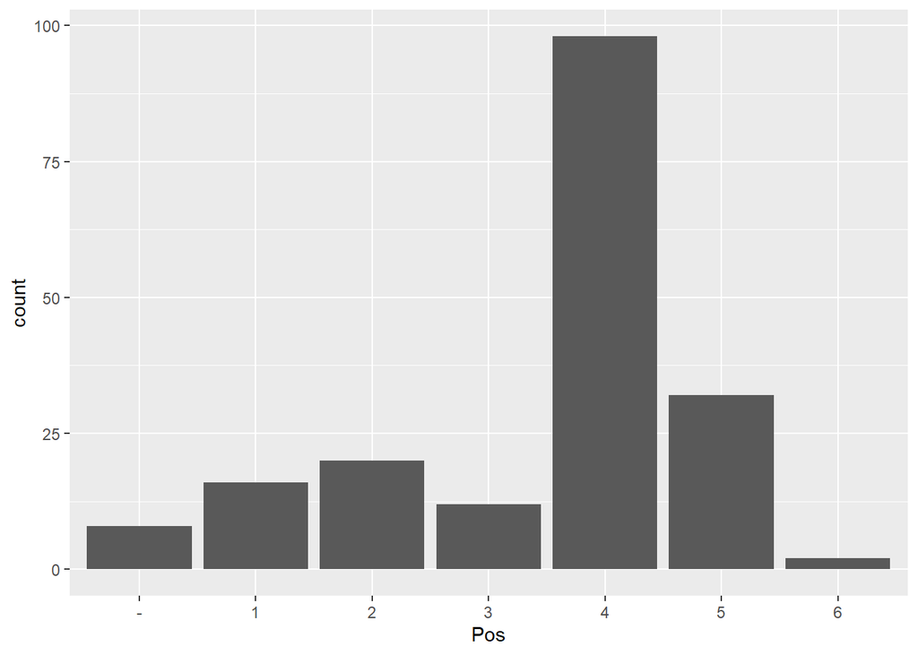

```r
ggplot(deVilliers, aes(x=Pos), col= 'Red') + geom_bar()
```

The above piece of R code plots the visualizations using bar chart where it shows the batting position of de Villiers throughout his career provided in datset from 2005 till 2015. We can clearly say that-

1. De Villiers batted almost 100 times at position 4, which is the most.
2. The second most times he batted at no. 5 which prove that he is predominantly a middle order batsman who batted at position 3, 4 and 5 most number of times in his career.

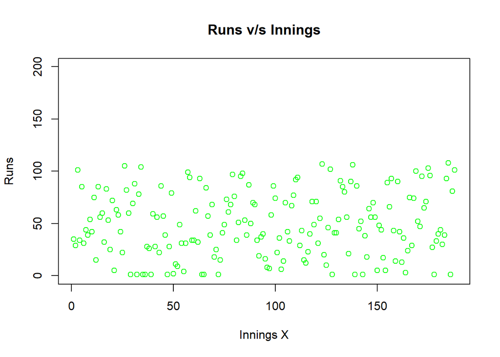

```r
plot(deVilliers$X,deVilliers$Runs, xlab = 'Innings X', ylab = 'Runs', main = 'Runs v/s Innings', col='Green', xlim =c(1,188),ylim = c(0,200))
```

The above chunk of R codes plots Runs versus Innings(X) where,

1. Horizontal x-axis is representing by no. of innings. There is a limit on it as well from 1 to 188 as 188 is the upper limit of innings provided in the data.
2. Vertical y-axis is representing Runs de Villiers scored. There is a limit on it from 0 to 200 as he got out on 0 few times and he never scored 200 as well in One day internationals in his career.

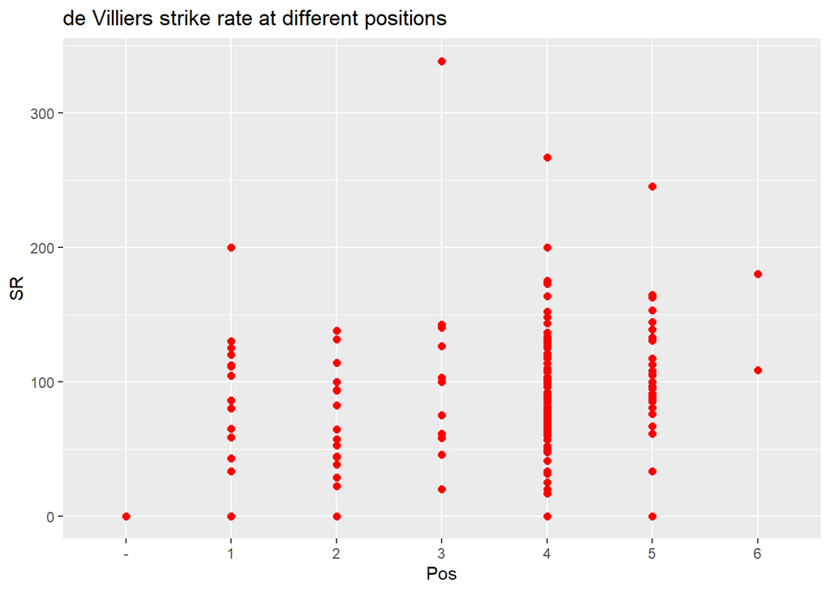

```r
ggplot(deVilliers, aes(x= Pos, y= SR)) + geom_point(col="Red", size= 2) + ggtitle("de Villiers strike rate at different positions") + geom_smooth(method = 'lm')
```

The above chunk of R codes plots the SR of de Villiers on all the positions he batted in his career where we can observe that-

### 2.3 Critical Appraisal of the tutorial

Critical appraisal is a process of assessing and examining the results of any research, evidence or data to state its reliability, trustworthiness and relevance within the field.

After working on the dataset deVilliers.csv, and if we read the whole complete dataset for the player from the most authentic and biggest database for Cricket, ESPNCricinfo, we understand that-

1. AB de Villiers is predominantly a middle order batsman who played most of his career at no. 4 position in ODI cricket.
2. Now retired from international duty as of 24th September 2020, AB de Villiers averaged 54 in ODI cricket with an overall SR of 101 in 228 ODIs which is phenomenal. The dataset we have contains some 188 entries till 2015 but till then, the dataset authenticates most of the batting attributes of his career correctly.

#### Scope of improvement

1. The dataset could cover a column where win percentage of his team, South Africa, be provided. Then it would have added more weight to de Villiers’ performances in team’s wins ratio.
2. In a more detailed approach, if somehow dataset can show the impact of de Villiers in setting the target while batting 1st or in chasing the target while batting 2nd and how they all fare in team’s winning cause, that will be more valuable dataset to work upon.

## Part 3: Journal Article

### Introduction of a journal of Sports Analytics: Naive Bayes (NB) approach

The paper talks about some findings of a study which are used to predict the winner of an ODI cricket match at the interval (after completion of 1st innings) using Naive Bayes approach. The data collected with 15 features comprising variables of batting, bowling and team composition. The objective of NB approach is to improve the accuracy of predicting the winner of the match after first inning, using selection algorithms such as univariate, recursive elimination and principle component analysis (PCA). The accuracy of predicting winner of ODI match becomes the highest (85.71%) with the univariate feature selection method. The accuracy can be further increased by selecting the appropriate ratio of the sample sizes of training sample to testing sample.

### Aim of the study

1. NB classifier is used as part of machine learning technique, to predict winner of an ODI match.
2. Using NB classifier, logistic regression, random forests and gradient boosted decision trees can also be used to help making predictions.

### Data collection

In this study of NB approach, they collected performance indicators representing 3 categories-

1. From batting point of view, total score of the inning, no. of centuries and half-centuries, no. of century and no. of half-centuries partnership are collected.
2. From bowling point of view, total no. of wickets fallen in an inning, total no. of dot balls, total no. of extras leaked in an inning are collected.
3. From team point of view, rank of teams, no. of batsmen, bowlers and all-rounders are collected.

### Analysis methods used

As per NB classifier approach, NB predicts the outcome of the match with 68% accuracy using the initial 5 overs and the accuracy is 91% towards the end of 45th over, in a 50 over ODI match.

NB classifier approach basically follow Bayes’ theorem which goes like,

1. P(Y=y| X=x)
2. =P(Y=y, X=x)/P(X=x)
3. =P(Y=y)P(X=x|Y=y)/P(x=x)
4. P(Y=y)P(X1=x1, X2=x2,……Xn=xn)/Sum of P(yi, X=x) where i is from 1 to C

In practice, P(X=x|Y=y) is assumed to follow a Gaussian distribution.

### Model Construction and Quantifying the performance

Let X = (X1, X2, X3……Xn)

where X1= Inning’s score X2= No. of centuries X3= No. of half-centuries and so on.

Xn= Batting away, be n = 15 dimensional vector

Let Y = (win,lose) be a random variable from domain Dy = (0,1).

For performance indicators,

TP = Predicting the actual win as a win FP = Predicting the actual lose as a win FN = Predicting the actual win as a lose TN = Predicting the actual lose as a lose

The perfect prediction indicates the value of the classification accuracy, 1(100%) and error rate of 0(0%). The entire algorithm is implemented using Python Anaconda 3.7 version.

Classification Accuracy = (TP + TN)/(TP + TN + FP + FN)

Error Rate = (FP + FN)/(TP + TN + FP + FN)

### Major findings and results

1. Based on the experimental outcomes, we find the highest accuracy of predicting the winning team is achieved when univariate feature selection technique is used with 85% : 15% of training to testing sample sizes.
2. The best prediction accuracy is 85.71% (that means the lowest error rate is 14.29%), which is quite good considering the unpredictable nature of the format of this sport Cricket.

### Critical appraisal and scope of improvements

1. As a whole, Naive Bayes approach is thought to be quite accurate, with best of 85% accuracy rate.
2. Taking a small sample size of 5 overs range in a 50 over innings is good in a way that it gives time and a substantial sample size for experiments and algorithms to be worked upon.
3. As an area of improvement, something can be done to predict the outcome of the match even while 2nd inning runs. It may improve the accuracy rate as it will cover more sample data after the completion of 1st innings.
4. There is another popular approach in Cricket, used to predict the winner of the match as well scores, called WASP (Win and score predictor). It can be utilized to relate and check upon the improvements of NB approach further.